# writeup_py

Xu Zhihao

11/12/2020

In this `python` tutorial, we mainly use the following package. `numpy` and `pandas` are used to read and process the data, `sklearn.linear_model` is used to fit the logistic regression model, `statsmodels.stats.weightstats` is used to construct the t-test with sample weight. All the algorithms related to propensity score weighting in this tutorial are implemented in `python`, but the tables and figures are visualized by `R(tidyverse)` using the output extracted from `python`. All the `python` variables are stored in a `R` list called `py` automatically and can be extracted by `$`.

```python
import numpy as np
import pandas as pd
from sklearn.linear_model import LogisticRegression
from statsmodels.stats.weightstats import ttest_ind
```

```python
nhanes = pd.read_csv('../data/nhanes.csv')
nhanes_X = nhanes.drop(columns=['id', 'heart_attack','diabete','weight'])
nhanes_diab = nhanes['diabete']
weight = nhanes['weight']
```

#### Estimate the Propensity Score by Fitting a Logistic Regression Model

```python
lg = LogisticRegression(random_state=0, max_iter = 1000)
lg.fit(nhanes_X, nhanes_diab, sample_weight = weight)
```

```
## LogisticRegression(max_iter=1000, random_state=0)
```

```python
prop_score = lg.predict_proba(nhanes_X)[:,1]
```

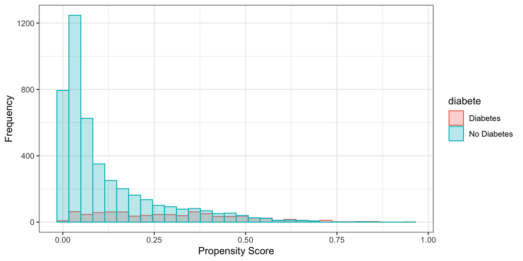

**Figure 1:** Propensity score distribution by Treated/Control Groups

Through **Figure 1**, we can see that, compared with diabetes patient, the non-diabetes patients usually have lower propensity scores. If we compare the `heart attack` rate directly, it is very likely to lead to a misleading result. Hence, we need to implement the Propensity Score Weighting/Matching to reduce the impact of covariates.

#### Propensity Score Matching by Nearest Neighbor

```python
dia_idx = np.where(nhanes['diabete'].values==1)
non_dia_idx = np.where(nhanes['diabete'].values==0)
prop_score_logit = np.log(prop_score / (1 - prop_score))
std = np.std(prop_score_logit[dia_idx])
result = [0]*len(prop_score_logit[dia_idx])
for i in range(len(prop_score_logit[dia_idx])):
    dif = prop_score_logit[dia_idx][i] - prop_score_logit[non_dia_idx]
    dif[np.array(result)[np.array(result)!=0]] = 100
    min_val = min(abs(dif))
    if min_val > 0.2*std:
        result[i] = 0
    else:
        result[i] = np.where(abs(dif)==min_val)[0][0]

result = np.array(result)
dia_idx_matched = dia_idx[0][result!=0]
result = result[result!=0]
matched_idx = non_dia_idx[0][result]
heart_matched = nhanes['heart_attack'].values[matched_idx]
heart_non_dia = nhanes['heart_attack'].values[non_dia_idx]
heart_dia_matched = nhanes['heart_attack'].values[dia_idx_matched]
```

```python
ttest_match = ttest_ind(heart_dia_matched, heart_matched, usevar='unequal',
                        weights=(weight[dia_idx_matched], weight[matched_idx]))
```

#### Estimate the Propensity Weights

```python
ps_weight = nhanes['diabete']/prop_score + (1 - nhanes['diabete'])/(1 - prop_score)
```

#### Balance Checking

```python
col = list(nhanes_X.columns)
result_mean_after = []
result_sd_after = []
for i in nhanes_X.columns:
    re_m = [np.average(nhanes_X[i][matched_idx],
                       weights=nhanes['weight'][matched_idx]),
            np.average(nhanes_X[i][dia_idx_matched],
                       weights=nhanes['weight'][dia_idx_matched])]
    re_sd = [np.sqrt(np.average((nhanes_X[i][matched_idx]-re_m[0])**2,
                                weights=nhanes['weight'][matched_idx])),
             np.sqrt(np.average((nhanes_X[i][dia_idx_matched]-re_m[1])**2,
                                weights=nhanes['weight'][dia_idx_matched]))]
    result_mean_after.append(re_m)
    result_sd_after.append(re_sd)

result_mean_before = []
result_sd_before = []
for i in nhanes_X.columns:
    re_m = [np.average(nhanes_X[i][non_dia_idx[0]],
                       weights=nhanes['weight'][non_dia_idx[0]]),
            np.average(nhanes_X[i][dia_idx[0]],
                       weights=nhanes['weight'][dia_idx[0]])]
    re_sd = [np.sqrt(np.average((nhanes_X[i][non_dia_idx[0]]-re_m[0])**2,
                                 weights=nhanes['weight'][non_dia_idx[0]])),
             np.sqrt(np.average((nhanes_X[i][dia_idx[0]]-re_m[1])**2,
                                 weights=nhanes['weight'][dia_idx[0]]))]
    result_mean_before.append(re_m)
    result_sd_before.append(re_sd)
```

##### Table 1: Before Matching

**Table 1:** Proportion of Heat Attack with Original Control Group

| Heart Attack | Non-diabetes | Diabetes |
| --- | --- | --- |
| No | 195463600( 97.8%) | 22122559( 85.2%) |
| Yes | 4398495( 2.2%) | 3830884( 14.8%) |

##### Table 2: After Matching

**Table 2:** Proportion of Heat Attack with Matched Control Group

| Heart Attack | Non-diabetes | Diabetes |
| --- | --- | --- |
| No | 27682914( 95.2%) | 21722158( 85.5%) |
| Yes | 1386160( 4.8%) | 3687518( 14.5%) |

##### Table 3: T-test

**Table 3:** Result of T-test

| T Statistic | p-value | degree of freedom |
| --- | --- | --- |
| 1213.742 | 0 | 40634737 |

##### Table 4: Inverse Weighting

**Table 4:** Proportion of Heat Attack with Inverse Propensity Score Weighting

| Heart Attack | Non-diabetes | Diabetes |
| --- | --- | --- |
| No | 220196223( 97.4%) | 209831249( 94.2%) |
| Yes | 5934056( 2.6%) | 13026733( 5.8%) |

##### Table 5: Balance Checking

**Table 5:** Balance Checking Table before and after matching

| Covariate | Before Matching Non-diabetes | Before Matching Diabetes | After Matching Non-diabetes | After Matching Diabetes |
| --- | --- | --- | --- | --- |
| relative_heart_attack | 0.122(0.328) | 0.198(0.399) | 0.190(0.392) | 0.190(0.393) |
| gender | 1.531(0.499) | 1.457(0.498) | 1.491(0.500) | 1.460(0.498) |
| age | 46.548(16.880) | 61.453(12.966) | 60.414(15.180) | 61.306(12.914) |
| race | 3.074(0.970) | 3.127(0.998) | 3.128(0.844) | 3.125(1.003) |
| edu | 3.815(1.079) | 3.540(1.171) | 3.621(1.150) | 3.554(1.167) |
| annual_income | 10.156(4.206) | 9.596(4.219) | 9.323(4.159) | 9.640(4.216) |
| bmi | 29.388(7.147) | 33.112(7.519) | 33.031(8.302) | 32.831(7.211) |
| smoke_life | 0.411(0.492) | 0.502(0.500) | 0.497(0.500) | 0.496(0.500) |
| phy_vigorous | 0.276(0.447) | 0.185(0.388) | 0.186(0.389) | 0.187(0.390) |
| phy_moderate | 0.493(0.500) | 0.409(0.492) | 0.419(0.493) | 0.417(0.493) |
| blood_press | 0.275(0.446) | 0.716(0.451) | 0.667(0.471) | 0.710(0.454) |
| blood_press2 | 0.220(0.414) | 0.599(0.490) | 0.566(0.496) | 0.591(0.492) |
| hyper_med | 0.237(0.425) | 0.694(0.461) | 0.643(0.479) | 0.687(0.464) |
| hbq_med | 0.185(0.388) | 0.633(0.482) | 0.550(0.498) | 0.625(0.484) |
| high_chol | 0.292(0.455) | 0.622(0.485) | 0.585(0.493) | 0.615(0.487) |
| meadial_access | 0.798(0.402) | 0.920(0.271) | 0.902(0.297) | 0.918(0.274) |
| cover_hc | 0.854(0.353) | 0.926(0.261) | 0.908(0.289) | 0.925(0.263) |
| health_diet | 1.988(0.999) | 1.852(0.951) | 1.924(0.987) | 1.849(0.951) |
| year_smoke | 12.573(18.633) | 21.881(24.265) | 20.283(23.306) | 21.519(24.056) |
| year_hyper | 3.090(7.335) | 10.982(12.875) | 9.469(11.572) | 10.862(12.782) |

#### Result Interpretation

Through **Table 1**, **Table 2** and **Table 4**, we can see that before matching/weighting, the rate of `heart attack` in diabetes patients is around 7 times larger than the non-diabetes patients. After matching/weighting, this rate decreases to only 2-3 times larger, which indicates that our matching/weighting significantly reduce the effect of the covariates. **Table 5** also shows similar result. Before matching, the `heart_attack` rate in `relative_heart_attack`, `age`, `bmi`, `blood_press`, `blood_press2`, `hyper_med`, `hbq_med`, `year_smoke` and `year_hyper` are significantly different between diabetes patients and non-diabetes patients. However, after matching, the rates in all corresponding covariates look similar, which is another evidence of the effect of propensity score matching. **Table 3** shows the t test result, which indicates that after matching, the `heart attack` rate in diabetes patients is still higher than the non-diabetes patients.